# SWA_Paired_AOI

Matt Webster

…

```
The purposes of this script are as follows:

COMPLETE THE FOLLOWING FOR ALL TARGET WATERSHEDS (n=6) in 2019, 2021, 2023:

  1) Import and organize data from various sources/source scripts:
    a) Surface water area (m2) per riparian polygon
    b) Riparian polygon geometries, and riparian polygon area (m2)
    c) Topographic Openness (no unit) per riparian polygon
    d) dynOcc data: grid cells, p, f, UDA
    e) Dam count per riparian polygon
      - beaver dams ('certain' and 'all' detections)
      - anthropogenic dams/channel spanning structures (e.g., road crossings, check dams, etc.)
  2) Implement density based cluster analysis of dammed stream reaches
    a) Max distance to be considered same cluster (Eps) = 250(m)
    b) Minimum dams for one cluster (minPoints) = 1 dam
  3) Implement paired sampling of dammed and undammed reaches
    a) Dammed/undammed not within 500m of 'anthro'
    b) Undammed pair = same stream length as dammed
    c) Undammed not within 500m of 'dammed'
    d) Undammed not within 250m of 'undammed' (force no overlap via spatial thinning)
  4) Compare surface water area (SWA) at dammed vs paired undammed reaches
  5) Visualize diff(SW) b/t dammed and undammed as heat map
    a) x axis is relative flow (2wk average for time t)
    b) y axis is ponding capacity (RIPA*(TO/90))

  5) Data needs:
    a. Surface Water Area [sum(SWA)] (m2) for cluster[i]
    b. Topographic Openness [mean(TO)] for cluster[i]
    c. Riparian Area [sum(RIPA)] (m2) for cluster[i]
    d. damIntensity/damDensity (Nhat) for cluster[i]
    e. Upstream drainage area [max(UDA)] (km2) for cluster[i] (a.k.a. contributing catchment are)
```

## Relative Flow Condition Across Study Period:

Visualize USGS flow data from Guston Coulee Gage on Beaver Ck, near Saco, MT.

Eventually, you’ll connect riparian inundation back to this for a post hoc heat map

Flow was z-standardized across [06/01-10/01] 2019, 2021, & 2023.

## 2019:

High early/mid-summer flow followed by moderate/low late season.

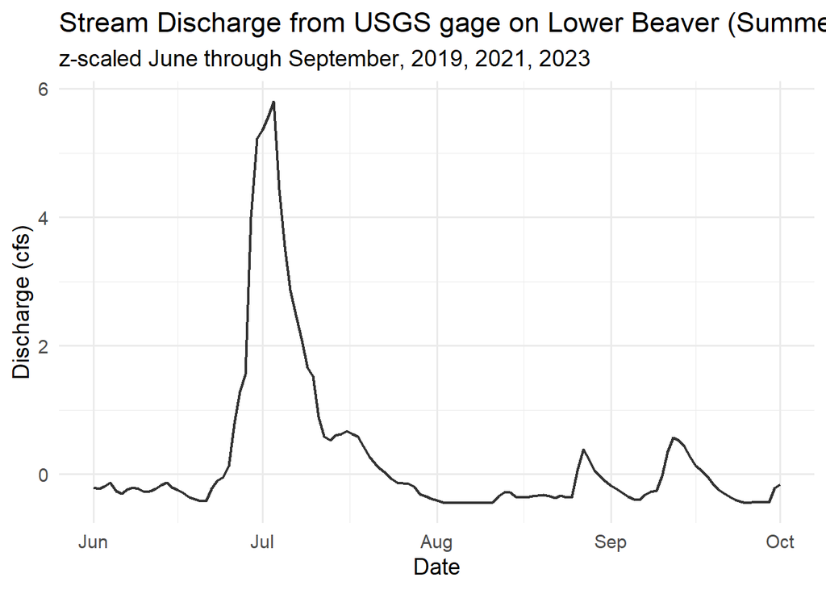

## 2021:

Low flow conditions throughout the summer season. Part of 3 year sustained drought conditions (2020, 2021, 2022).

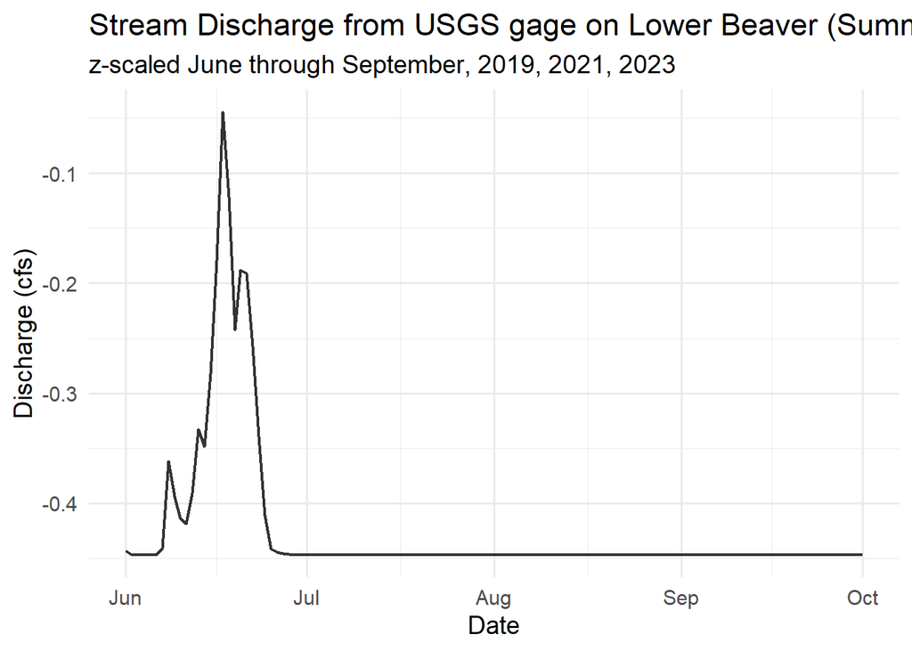

## 2023:

High early flow conditions followed by moderate to lower late summer.

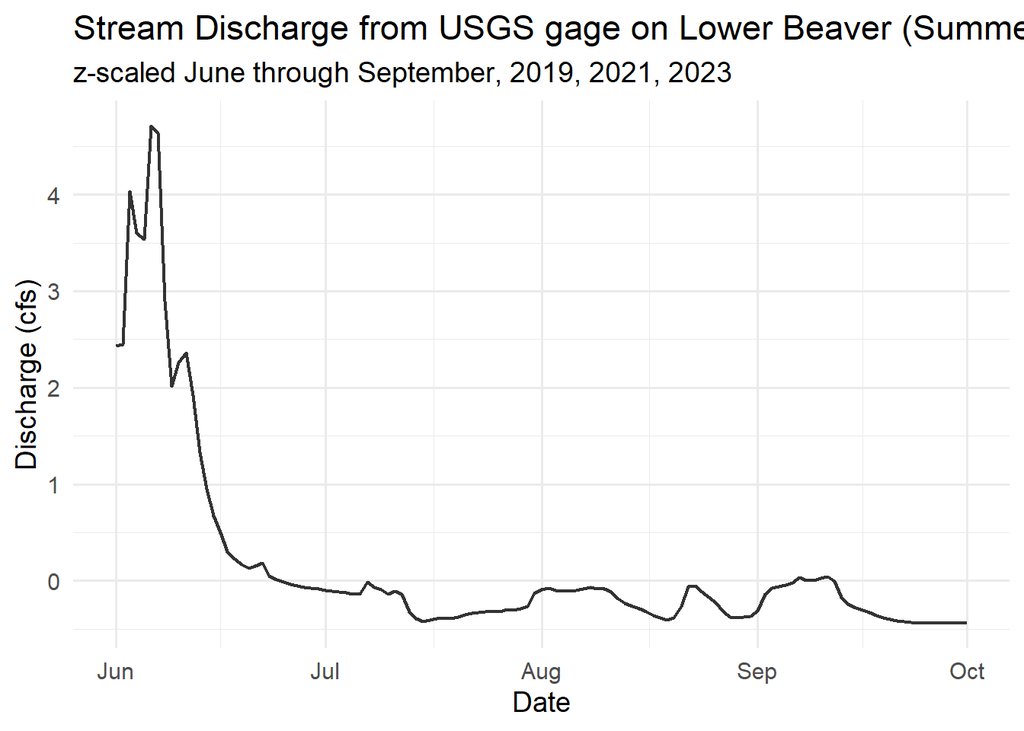

Visualize temporally static variables of interest:

```
These are variables that a constant per riparian polygon over time. TO and riparian area come from a 1m DEM from 2019, and are considered constant for our purposes. Ditto with catchment area, though it was derived from NHDplus-HR, I believe (double check with CP).
```

## Topographic Openness Across Study Area

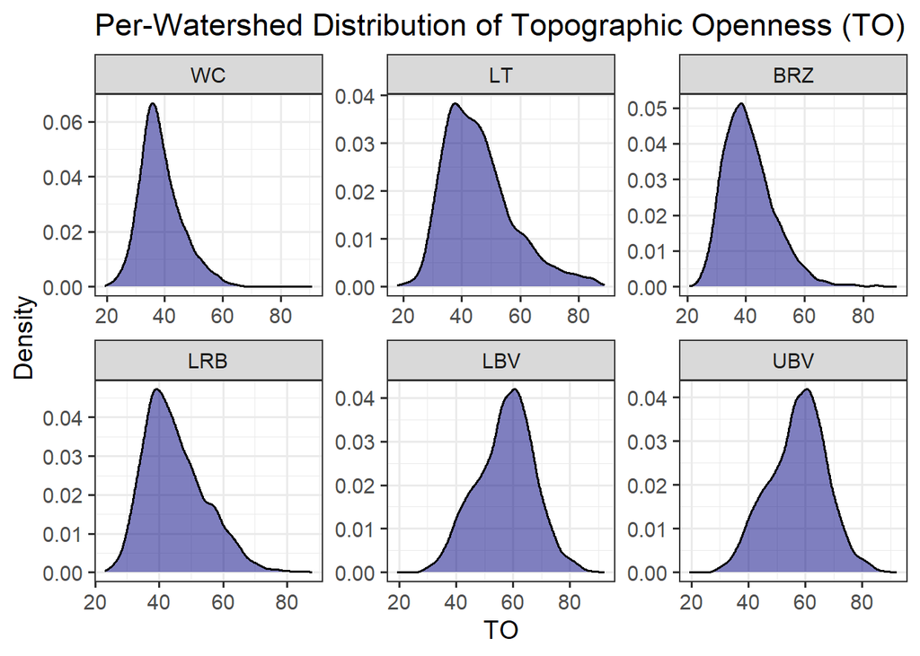

## Riparian Area Across Study Area

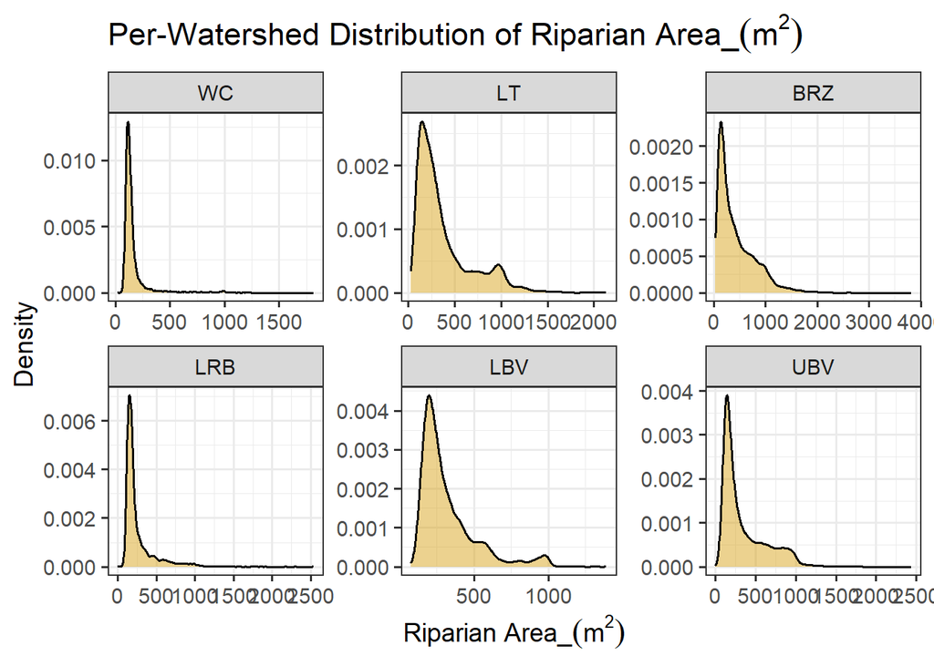

## Contributing Drainage Area Across Study Area

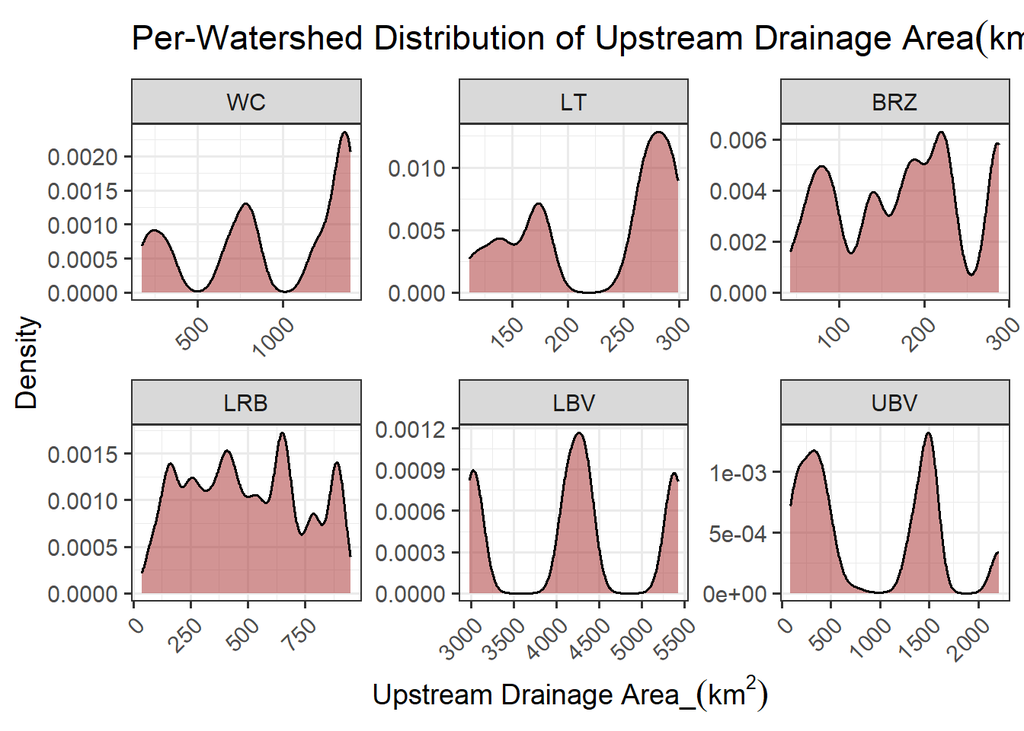

Get dam detections and surface water area for each riparian polygon, in each watershed, during each time period, in each year.

Dams [line 806:1811]

## —-

Identify dammed and undammed sample clusters using **1-D DBSCAN** (Density Based Spatial clustering Algorithm with Noise).

```
1-D DBSCAN uses TP_ID as a 1-D directional marker (following the stream flow
line). TP_IDs are ~10-m spaced. DBSCAN uses a minCluster size of 1 dam, and
a max distance for inclusion in a cluster of 250-m between dams.

Min(ClusterSize) = 1 dammed polygon
eps = 25


NOTE:
  - NOT DOING EPS[optimal] approach. Test clustering using 25 and test
    clustering using 10; Make a call.
  - Median distance between nearest neighbors is 300-m on Willow Ck 2021.
    Thus, less than 300m could be considered 'closer than normal';
    go with 250-m
  - At Eps=10 (100m search) just about every dam on WC21 is it's own cluster
    (155 dams, 126 clusters).
```

**Willow Creek**

**Lone Tree Creek**

**Brazil Creek**

**Larb Creek**

**LowBeav Creek**

**Upper Beav Creek**

```
## sf [18,125 × 13] (S3: sf/tbl_df/tbl/data.frame)
##  $ TP_ID              : num [1:18125] 1 2 3 4 5 6 7 8 9 10 ...
##  $ year               : num [1:18125] 2019 2019 2019 2019 2019 ...
##  $ unique_ID          : chr [1:18125] "UBV_1657" "UBV_1657" "UBV_1657" "UBV_1657" ...
##  $ TO                 : num [1:18125] 64.7 75 61.8 57 56.4 ...
##  $ catchment_km2      : num [1:18125] 2213 2213 2213 2213 2213 ...
##  $ p_mean             : num [1:18125] 0.907 0.907 0.907 0.907 0.907 ...
##  $ f_mean             : num [1:18125] 0.0194 0.0194 0.0194 0.0194 0.0194 ...
##  $ geometry           :sfc_GEOMETRY of length 18125; first list element: List of 1
##   ..$ : num [1:4, 1:2] 310070 310068 310071 310070 5326609 ...
##   ..- attr(*, "class")= chr [1:3] "XY" "POLYGON" "sfg"
##  $ watershed          : chr [1:18125] "UBV" "UBV" "UBV" "UBV" ...
##  $ dam_count_beav_all : int [1:18125] 0 0 0 0 0 0 0 0 0 0 ...
##  $ dam_count_beav_conf: int [1:18125] 0 0 0 0 0 0 0 0 0 0 ...
##  $ dam_count_ant      : int [1:18125] 0 0 0 0 0 0 0 0 0 0 ...
##  $ isAnthro           : int [1:18125] 0 0 0 0 0 0 0 0 0 0 ...
##  - attr(*, "sf_column")= chr "geometry"
##  - attr(*, "agr")= Factor w/ 3 levels "constant","aggregate",..: NA NA NA NA NA NA NA NA NA NA ...
##   ..- attr(*, "names")= chr [1:12] "TP_ID" "year" "unique_ID" "TO" ...
```

**Implement DBSCAN:**

```
Criteria:
---------
  - minDams per Cluster = 1
  - eps = 250-m = 25-TP_ID

  - 'Beaver dammed' polygons must be >= 500-m from a 'anthropogenically
    dammed' polygon to limit the potential confounding effect on beaver v. non.
```

## WILLOW

## **2019**

**VISUALIZE DAM CLUSTERS:**

Plot dam clusters for Willow Creek 2019 on a map:

[interactive chart not shown]

## **2021**

**VISUALIZE DAM CLUSTERS:**

Plot dam clusters for Willow Creek 2021 on a map:

[interactive chart not shown]

## **2023**

**VISUALIZE DAM CLUSTERS:**

Plot dam clusters for Willow Creek 2023 on a map:

[interactive chart not shown]

—>

**DEFINE PAIRED UNDAMMED REACHES:**

```
- Undammed sample reaches must be:
  - interspersed between dammed reaches
  - (>=) 500m from nearest dam
  - 'paired' with a nearby dam cluster
  - (>=) 250m from nearest undammed (forced thinning post-pairing)
```

## **2019**

**Visualize Sample Reaches for Willow Creek 2019:**

[interactive chart not shown]

```
## [1] 22
```

## **2021**

**Visualize Sample Reaches for Willow Creek 2021:**

[interactive chart not shown]

```
## [1] 26
```

## **2023**

**Visualize Sample Reaches for Willow Creek 2023:**

[interactive chart not shown]

```
## [1] 19
```

## LONE TREE

## **2019**

**VISUALIZE DAM CLUSTERS:**

Plot sample regions for Willow Creek 2019 on a map:

[interactive chart not shown]

## **2021**

**VISUALIZE DAM CLUSTERS:**

Plot sample regions for Willow Creek 2021 on a map:

[interactive chart not shown]

## **2023**

**VISUALIZE DAM CLUSTERS:**

Plot sample regions for Willow Creek 2023 on a map:

[interactive chart not shown]

—>

**DEFINE PAIRED UNDAMMED REACHES:**

```
- Undammed sample reaches must be:
  - interspersed between dammed reaches
  - (>=) 500m from nearest dam
  - 'paired' with a nearby dam cluster
  - (>=) 250m from nearest undammed (forced thinning post-pairing)
```

## **2019**

**Visualize Sample Reaches for Lone Tree Creek 2019:**

[interactive chart not shown]

```
## [1] 9
```

## **2021**

**Visualize Sample Reaches for Lone Tree Creek 2021:**

[interactive chart not shown]

```
## [1] 8
```

## **2023**

**Visualize Sample Reaches for Lone Tree Creek 2023:**

[interactive chart not shown]

```
## [1] 13
```

## BRAZIL

## **2019**

**VISUALIZE DAM CLUSTERS:**

Plot sample regions for Willow Creek 2019 on a map:

[interactive chart not shown]

## **2021**

**VISUALIZE DAM CLUSTERS:**

Plot sample regions for Willow Creek 2021 on a map:

[interactive chart not shown]

## **2023**

**VISUALIZE DAM CLUSTERS:**

Plot sample regions for Willow Creek 2023 on a map:

[interactive chart not shown]

—>

**DEFINE PAIRED UNDAMMED REACHES:**

```
- Undammed sample reaches must be:
  - interspersed between dammed reaches
  - (>=) 500m from nearest dam
  - 'paired' with a nearby dam cluster
  - (>=) 250m from nearest undammed (forced thinning post-pairing)
```

## **2019**

**Visualize Sample Reaches for Brazil Creek 2019:**

[interactive chart not shown]

```
## [1] 8
```

## **2021**

**Visualize Sample Reaches for Brazil Creek 2021:**

[interactive chart not shown]

```
## [1] 10
```

## **2023**

**Visualize Sample Reaches for Brazil Creek 2023:**

[interactive chart not shown]

```
## [1] 15
```

## LARB

## **2019**

**VISUALIZE DAM CLUSTERS:**

Plot sample regions for Willow Creek 2019 on a map:

[interactive chart not shown]

## **2021**

**VISUALIZE DAM CLUSTERS:**

Plot sample regions for Willow Creek 2021 on a map:

[interactive chart not shown]

## **2023**

**VISUALIZE DAM CLUSTERS:**

Plot sample regions for Willow Creek 2023 on a map:

[interactive chart not shown]

—>

**DEFINE PAIRED UNDAMMED REACHES:**

```
- Undammed sample reaches must be:
  - interspersed between dammed reaches
  - (>=) 500m from nearest dam
  - 'paired' with a nearby dam cluster
  - (>=) 250m from nearest undammed (forced thinning post-pairing)
```

## **2019**

**Visualize Sample Reaches for Larb Creek 2019:**

[interactive chart not shown]

```
## [1] 16
```

## **2021**

**Visualize Sample Reaches for Larb Creek 2021:**

[interactive chart not shown]

```
## [1] 26
```

## **2023**

**Visualize Sample Reaches for Larb Creek 2023:**

[interactive chart not shown]

```
## [1] 18
```

## LOW BEAV

## **2019**

**VISUALIZE DAM CLUSTERS:**

Plot sample regions for Willow Creek 2019 on a map:

[interactive chart not shown]

## **2021**

**VISUALIZE DAM CLUSTERS:**

Plot sample regions for Willow Creek 2021 on a map:

[interactive chart not shown]

## **2023**

**VISUALIZE DAM CLUSTERS:**

Plot sample regions for Willow Creek 2023 on a map:

[interactive chart not shown]

—>

**DEFINE PAIRED UNDAMMED REACHES:**

```
- Undammed sample reaches must be:
  - interspersed between dammed reaches
  - (>=) 500m from nearest dam
  - 'paired' with a nearby dam cluster
  - (>=) 250m from nearest undammed (forced thinning post-pairing)
```

## **2019**

**Visualize Sample Reaches for Lower Beaver Creek 2019:**

[interactive chart not shown]

```
## [1] 2
```

## **2021**

**Visualize Sample Reaches for Lower Beaver Creek 2021:**

[interactive chart not shown]

```
## [1] 11
```

## **2023**

**Visualize Sample Reaches for Lower Beaver Creek 2023:**

[interactive chart not shown]

```
## [1] 22
```

## UPPER BEAVER

## **2019**

**VISUALIZE DAM CLUSTERS:**

Plot sample regions for Willow Creek 2019 on a map:

[interactive chart not shown]

## **2021**

**VISUALIZE DAM CLUSTERS:**

Plot sample regions for Willow Creek 2021 on a map:

[interactive chart not shown]

## **2023**

**VISUALIZE DAM CLUSTERS:**

Plot sample regions for Willow Creek 2023 on a map:

[interactive chart not shown]

—>

**DEFINE PAIRED UNDAMMED REACHES:**

```
- Undammed sample reaches must be:
  - interspersed between dammed reaches
  - (>=) 500m from nearest dam
  - 'paired' with a nearby dam cluster
  - (>=) 250m from nearest undammed (forced thinning post-pairing)
```

## **2019**

**Visualize Sample Reaches for Upper Beaver Creek 2019:**

[interactive chart not shown]

```
## [1] 25
```

## **2021**

**Visualize Sample Reaches for Upper Beaver Creek 2021:**

[interactive chart not shown]

```
## [1] 38
```

## **2023**

**Visualize Sample Reaches for Upper Beaver Creek 2023:**

[interactive chart not shown]

```
## [1] 29
```

## —-

Surface Water Area

**Willow Creek**

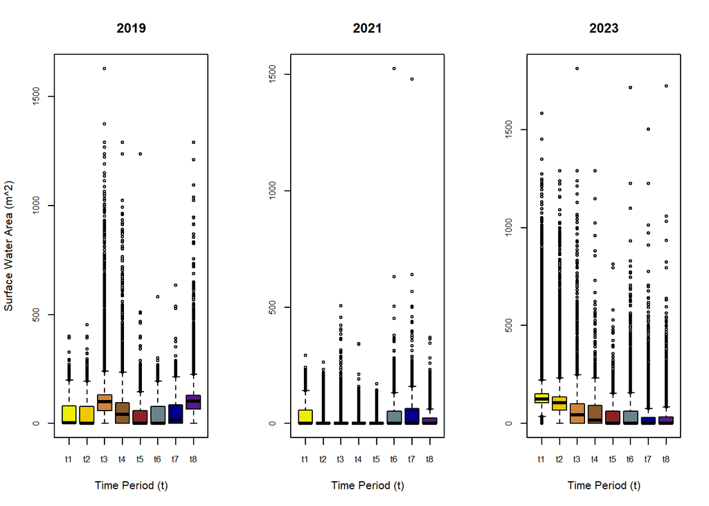

**Lone Tree Creek**

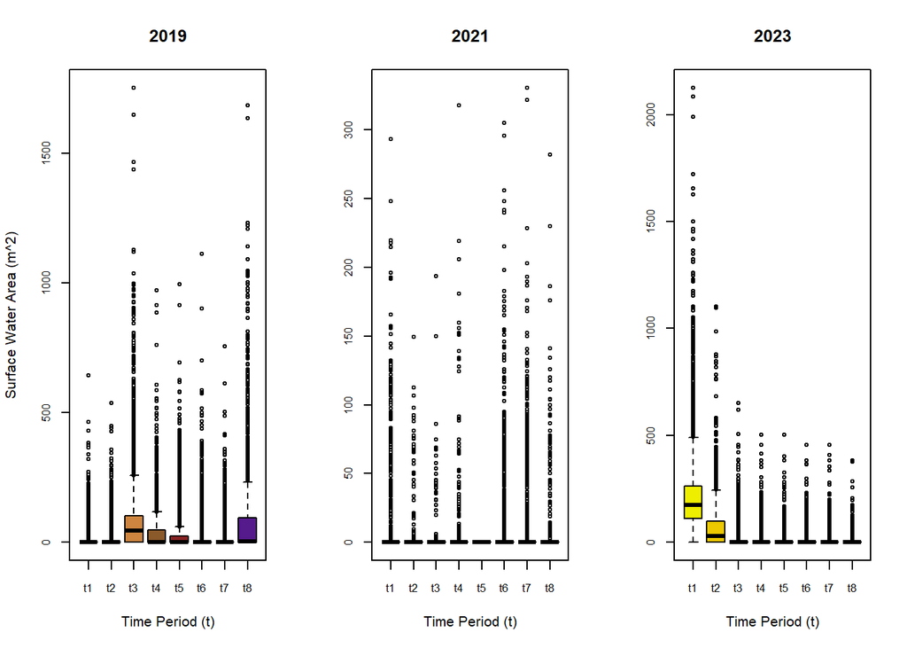

**Brazil Creek**

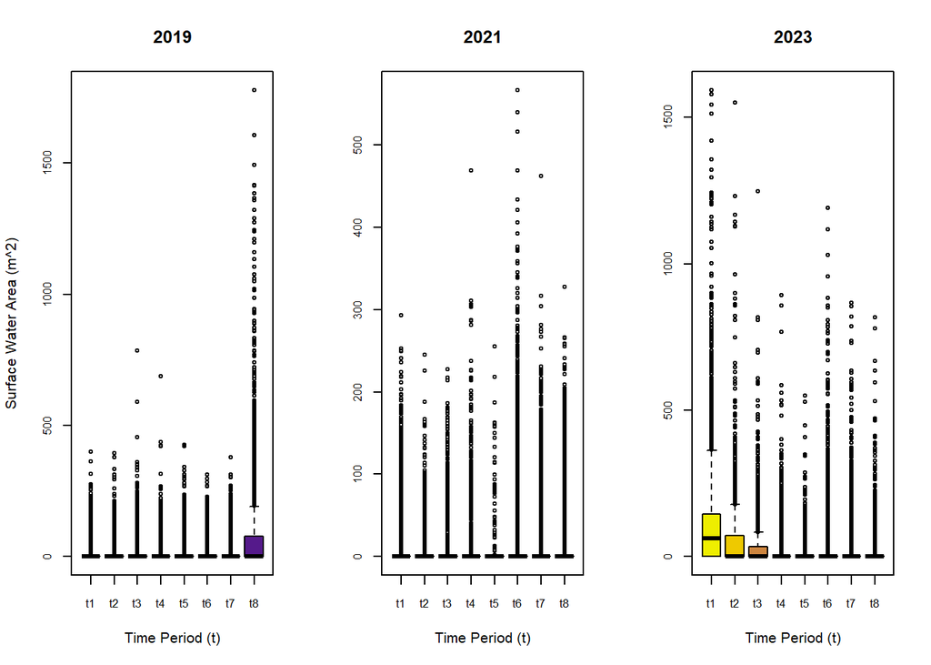

**Larb Creek**

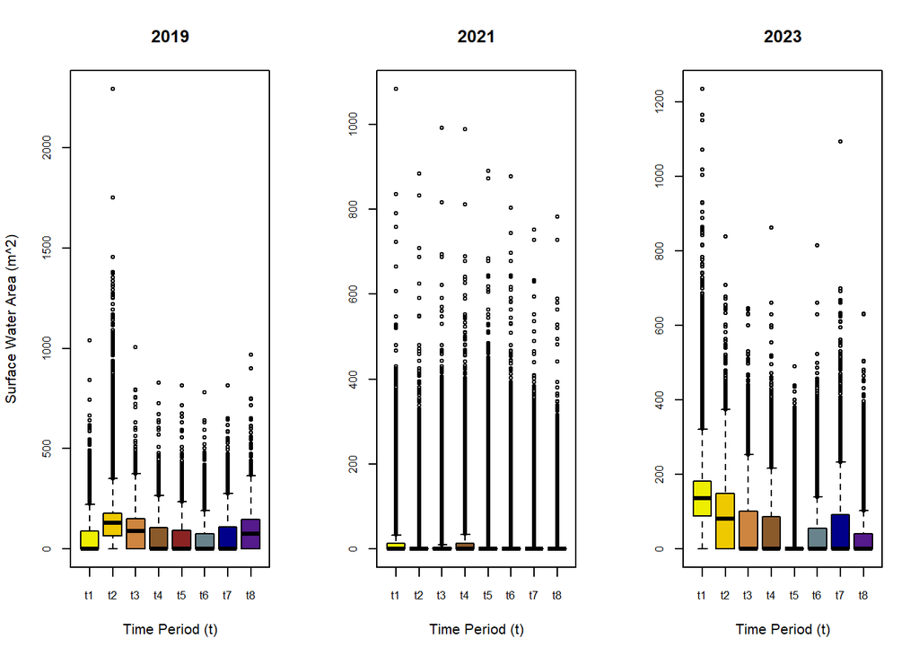

**Lower Beaver Creek**

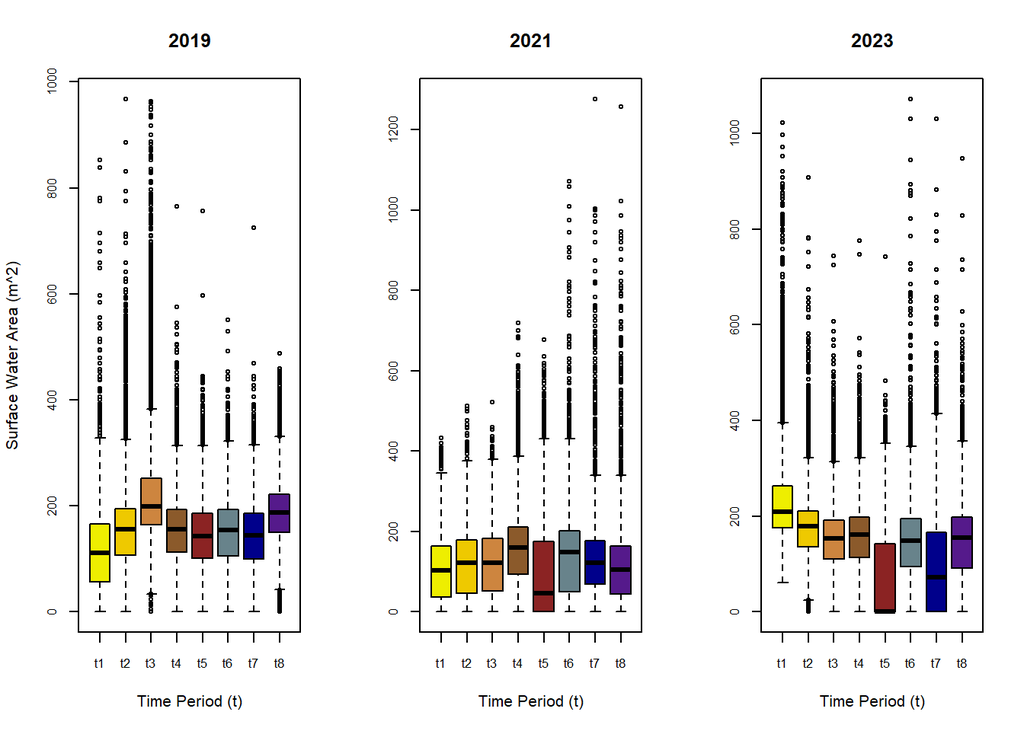

**Upper Beaver Creek**

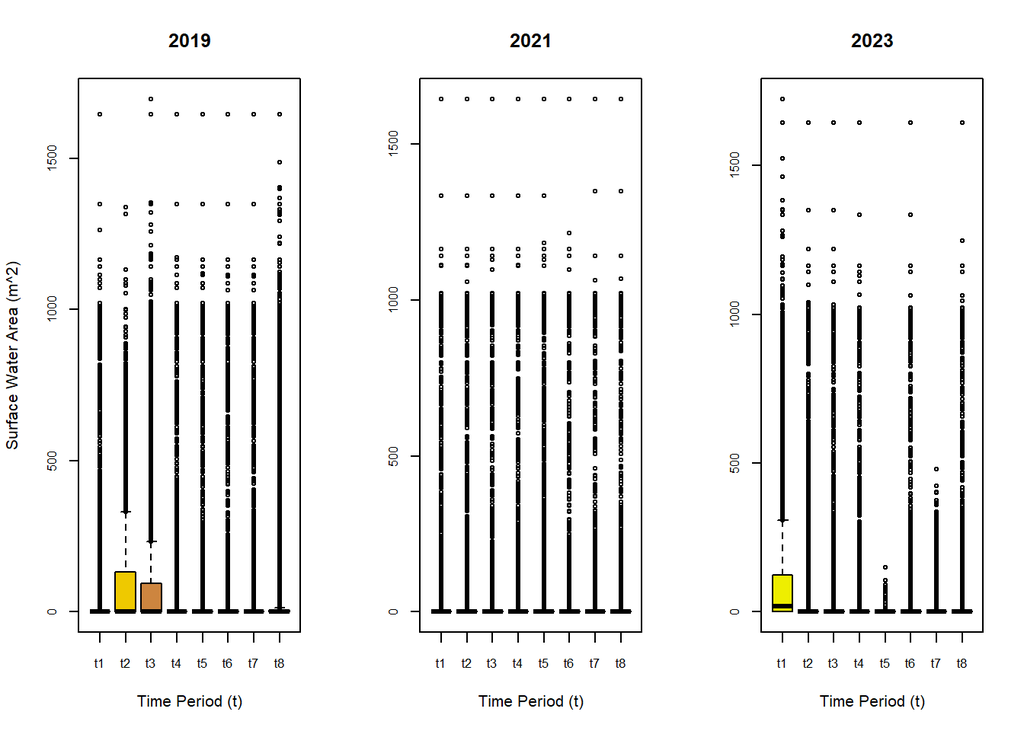

## —-

Now sample SWA for dammed and undammed clusters, and finalize data frames for summary and analysis:

```
The goal is to end up with a dataframe in long format where columns =

  - ClusterID_seq: (1:n)
  - Window_type: 'dammed' v 'undammed'
  - sum_c: summed dam count for window
  - mean_p: avg det prob for window
  - mean_f: avg fp prob for window
  - Nhat: est. dam count, considering mean(p,fp)
  - TO_mean: mean TO for window
  - RIP_Area_m2: total riparian area in (m^2)
  - UDA: contributing catchment area in (km^2)
  - containsNull: Impacted by satellite obfuscation
  - timePeriod: sample period 1:8; 2wk subdivisions of (June 01 - Sept 30).
  - SWA: summed surface water area of window
```

## **WILLOW**

## **2019**

[figure not shown]

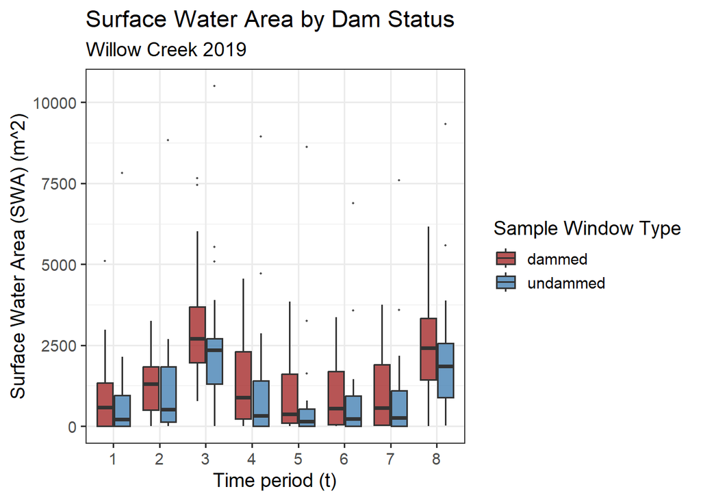

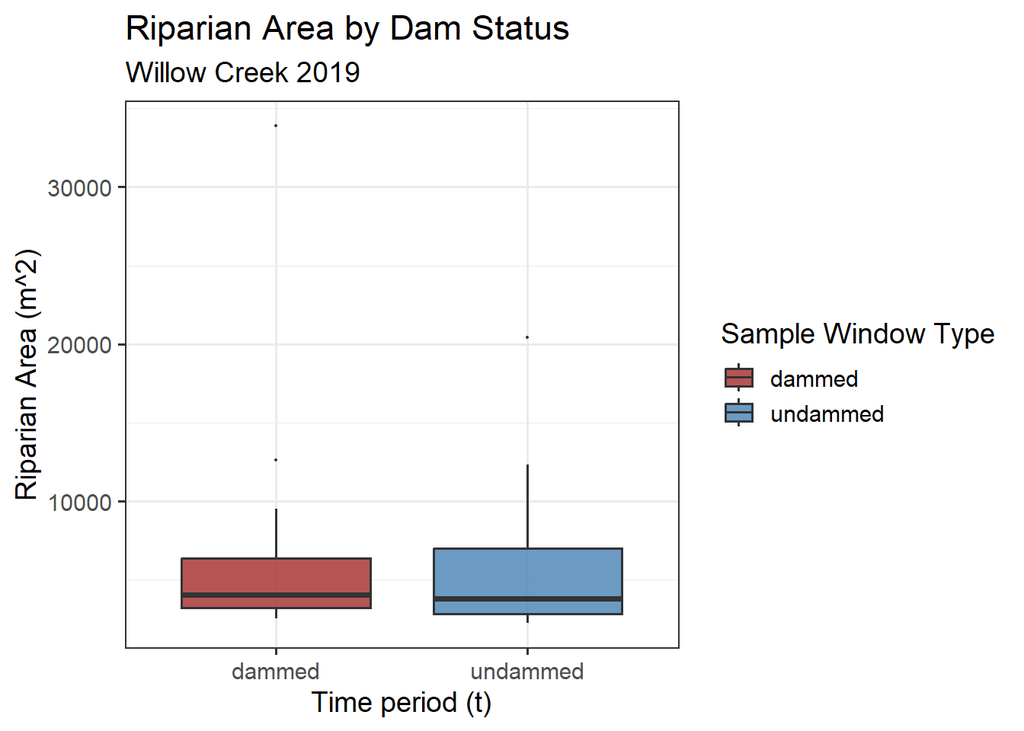

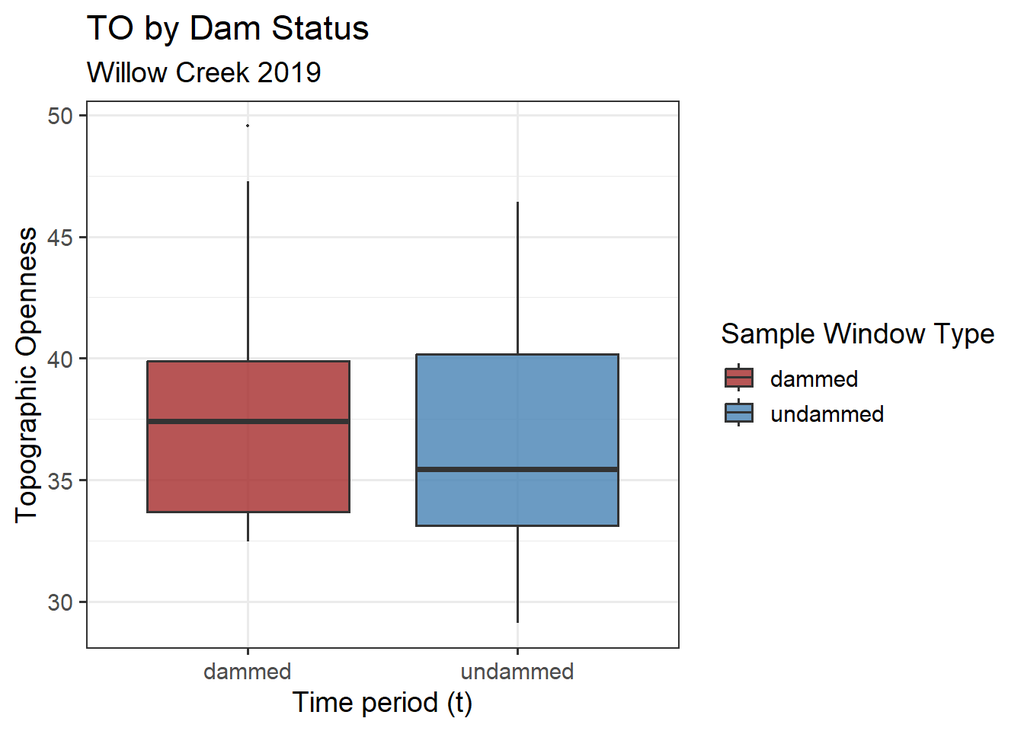

## **2021**

[figure not shown]

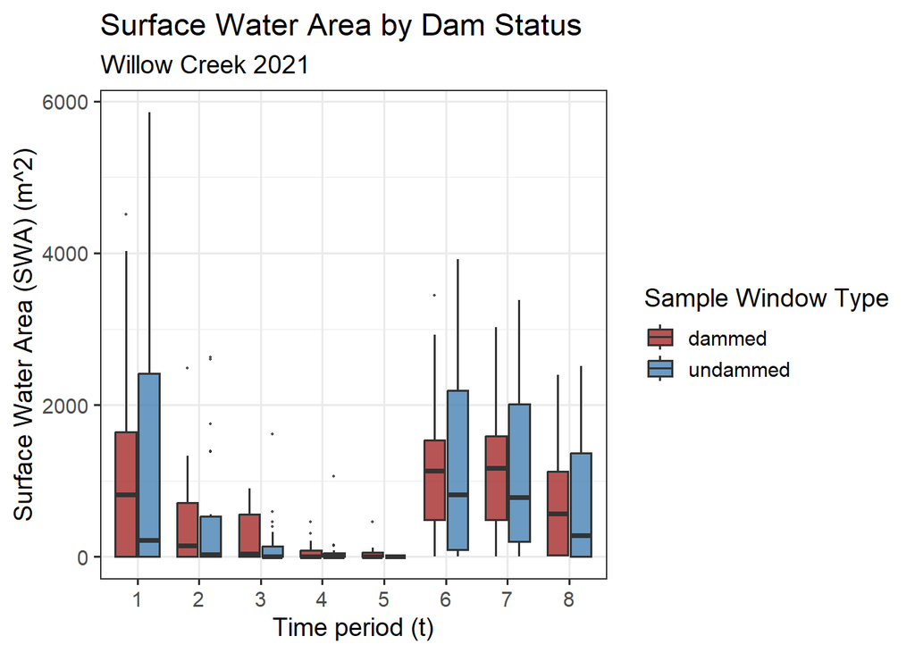

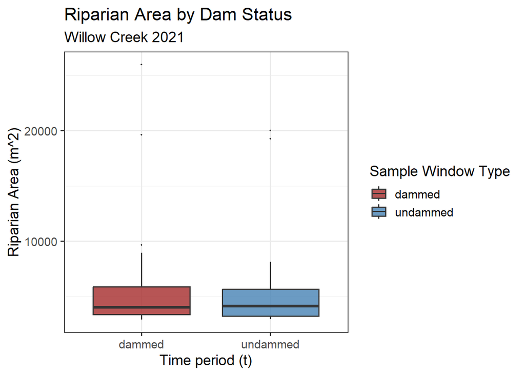

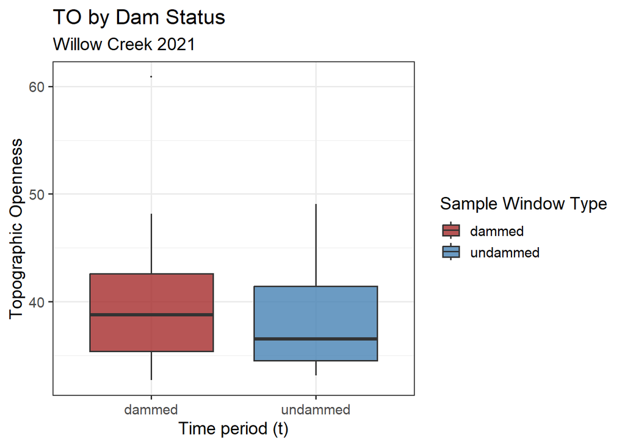

## **2023**

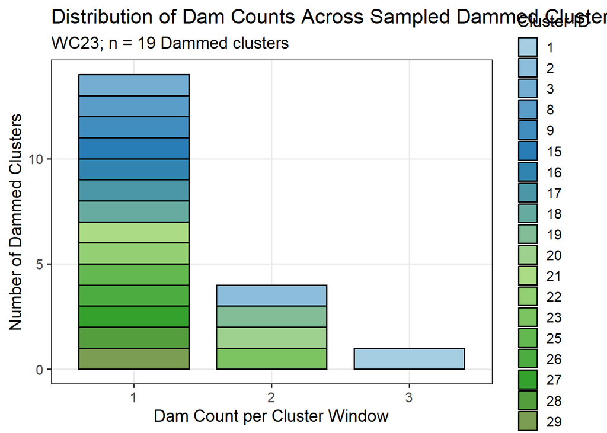

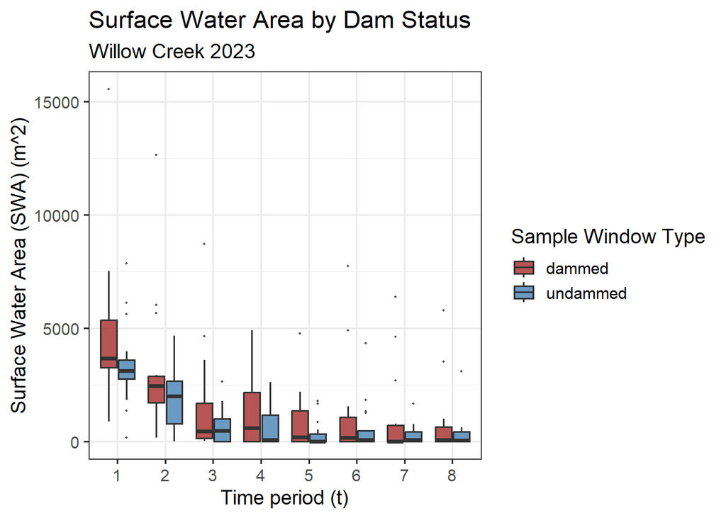

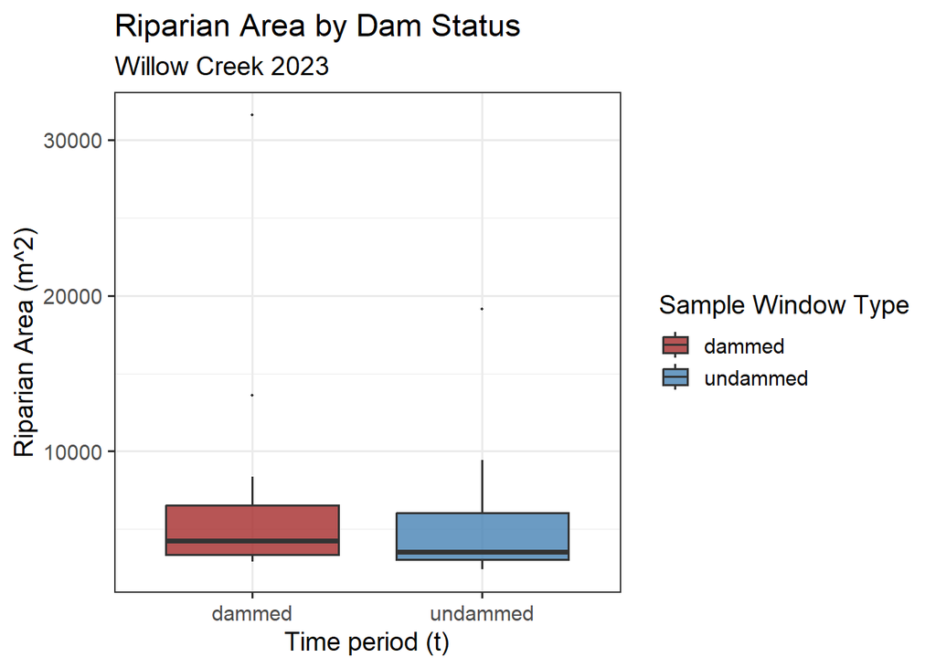

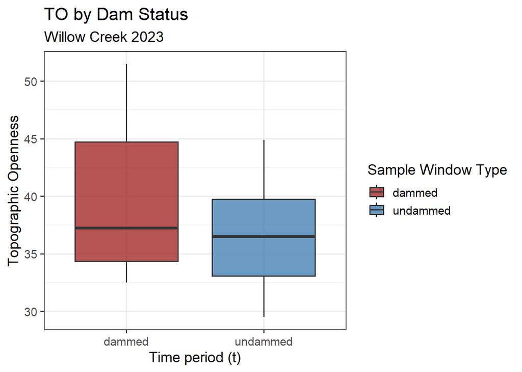

## —-

## —-

## **LONE TREE**

## **2019**

[figure not shown]

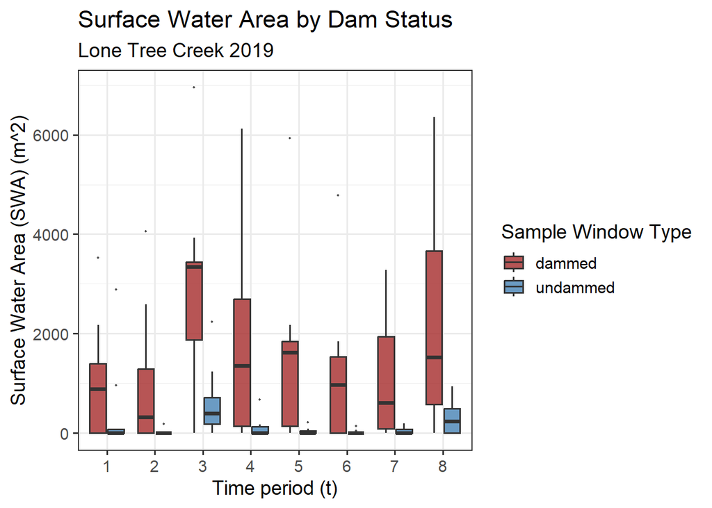

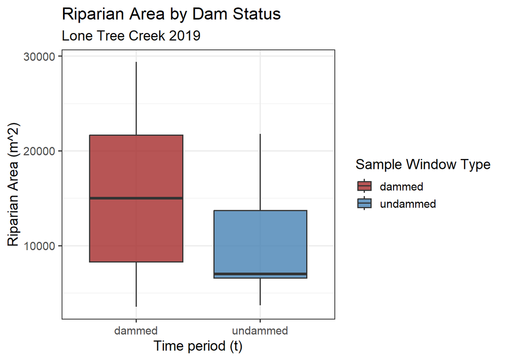

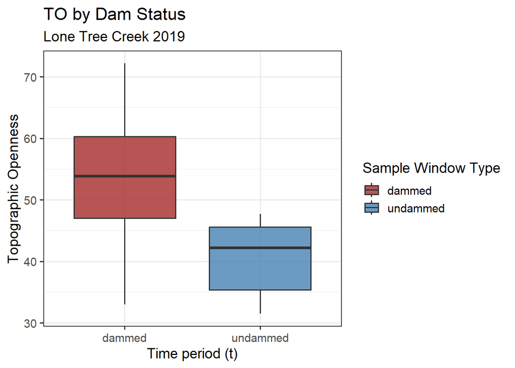

## **2021**

[figure not shown]

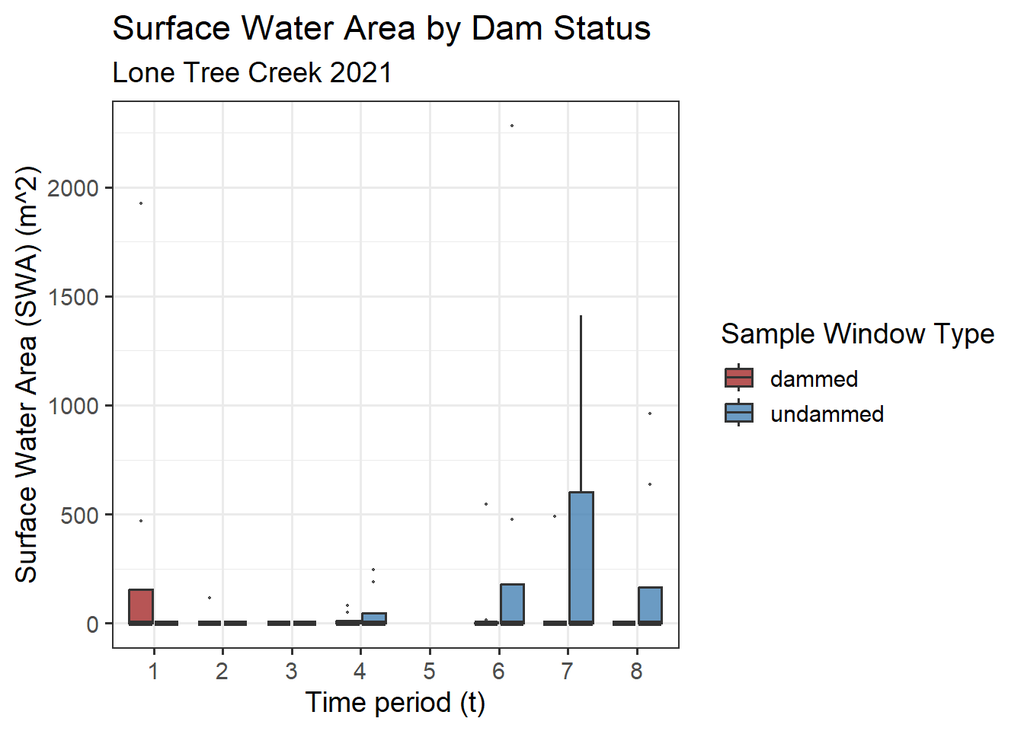

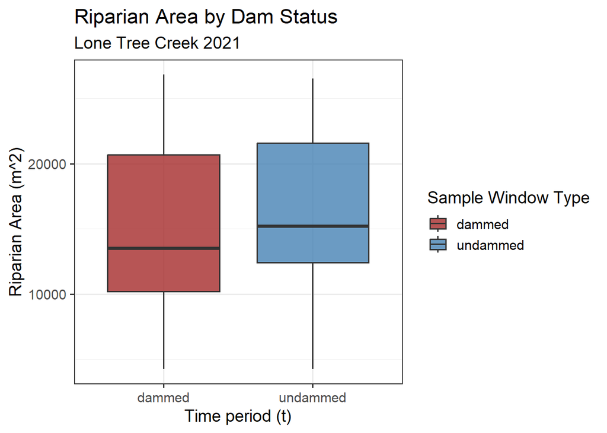

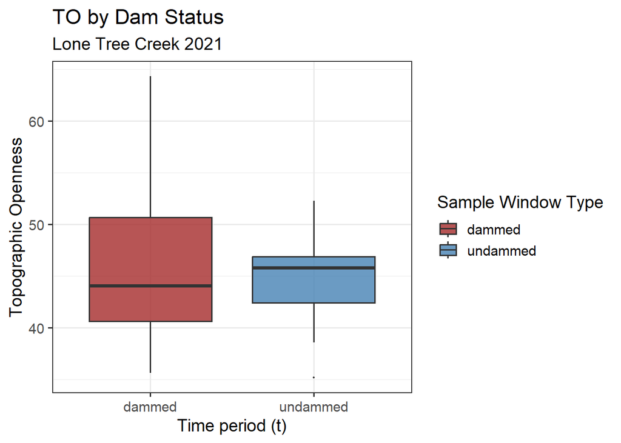